# Notebook

### 영화 배우별 관객수, 장르 분석

#### 분석 목적

**1.영화 배우별 관객수 순위 분석**  
영화 흥행에 있어서 배우의 캐스팅은 중요한 요소이다. 영화 관객수는 영화 흥행을 판가름하는 결정적인 요소이고, 기존에 배우가 출연한 영화들의 관객수 분포를 통해 영화 배우의 가치를 가늠할 수 있을 것이다. 이때 어떤 배우의 흥행작이 아무리 많더라도 그만큼 실패작이 많다면 영화사에서 그 배우를 캐스팅 하기에 부담이 될 수 있다. 그래서 배우별 영화 한편당 **평균 동원 관객수**와 **분산**을 통해 배우의 가치 평가에 활용하고자 한다.

**2.영화 배우별 강세 장르 분석**  
또한 특정 배우가 어떤 **장르**(코미디, 액션, 판타지 등) 에서 강세를 보이는지에 대한 분석을 통해 영화 특성에 맞는 적합한 배우 선택에 도움이 될 수도 있을 것이다.

### 데이터 요약

**영화 정보 데이터(movies_refined.csv) :**  
*영화 개봉일자 및 관객수 데이터(관객수 오차 0.1% 내외)*  
*2015~2019 개봉 영화 중 관객수 1만 이상 영화 대상*  
**openDt** : 영화 개봉 일자  
**companys** : 제작사, 배급사  
**audiAcc** : 영화 관객수  
**audits** : 관람등급  
**actors** : 출연 배우  
**firstGenre : 영화 대표 장르  
**actorLen** : 출연 배우 수

**출처 : KOBIS API**  
http://www.kobis.or.kr/kobisopenapi/homepg/main/main.do

### 영화 정보 데이터

|  | movieNm | showTm | openDt | typeNm | genres | companys | audiAcc | audits | actors | year | season | dateMonth | firstGenre | actorLen |
| --- | --- | --- | --- | --- | --- | --- | --- | --- | --- | --- | --- | --- | --- | --- |
| 300 | 극한직업 | 111 | 2019-01-23 | 장편 | [코미디] | [{'companyNm': '(주)어바웃필름', 'companyCd': '20140... | 16264131 | 15세이상관람가 | [류승룡, 이하늬, 진선규, 이동휘, 공명, 양현민, 장진희, 한준우, 김명준, 나... | 2019 | winter | 2019-01-01 | 코미디 | 82 |
| 222 | 신과함께-죄와 벌 | 139 | 2017-12-20 | 장편 | [판타지, 드라마] | [{'companyNm': '리얼라이즈픽쳐스(주)', 'companyCd': '20... | 14410195 | 12세이상관람가 | [하정우, 차태현, 주지훈, 김향기, 마동석, 김동욱, 도경수, 오달수, 임원희, ... | 2017 | winter | 2017-12-01 | 판타지 | 41 |
| 37 | 베테랑 | 123 | 2015-08-05 | 장편 | [액션, 드라마] | [{'companyNm': '(주)외유내강', 'companyCd': '201003... | 13411589 | 15세이상관람가 | [황정민, 유아인, 유해진, 오달수, 장윤주, 김시후, 오대환, 정웅인, 정만식, ... | 2015 | summer | 2015-08-01 | 액션 | 48 |
| 36 | 암살 | 139 | 2015-07-22 | 장편 | [액션, 드라마] | [{'companyNm': '(주)케이퍼필름', 'companyCd': '20062... | 12706663 | 15세이상관람가 | [전지현, 이정재, 하정우, 오달수, 조진웅, 이경영, 최덕문, 김의성, 박병은, ... | 2015 | summer | 2015-07-01 | 액션 | 44 |
| 265 | 신과함께-인과 연 | 141 | 2018-08-01 | 장편 | [판타지, 드라마] | [{'companyNm': '리얼라이즈픽쳐스(주)', 'companyCd': '20... | 12274846 | 12세이상관람가 | [하정우, 주지훈, 김향기, 마동석, 김동욱, 이정재, 김기태, 오희준, 도경수, ... | 2018 | summer | 2018-08-01 | 판타지 | 51 |

### 영화배우 데이터

|  | actor | audiMean | audiStd | count | movieNm | relativeStd |
| --- | --- | --- | --- | --- | --- | --- |
| 0 | 황정민 | 7.413820e+06 | 3.452636e+06 | 7 | [베테랑, 히말라야, 검사외전, 곡성, 아수라, 군함도, 공작] | 0.465703 |
| 1 | 하정우 | 7.053106e+06 | 4.922252e+06 | 9 | [허삼관, 암살, 아가씨, 터널, 신과함께-죄와 벌, 1987, 신과함께-인과 연,... | 0.697884 |
| 2 | 주지훈 | 6.524778e+06 | 5.475894e+06 | 6 | [간신, 아수라, 신과함께-죄와 벌, 신과함께-인과 연, 공작, 암수살인] | 0.839246 |
| 3 | 송강호 | 6.474883e+06 | 4.440171e+06 | 6 | [사도, 밀정, 택시운전사, 마약왕, 기생충, 나랏말싸미] | 0.685753 |
| 4 | 이정재 | 6.221949e+06 | 6.167045e+06 | 8 | [암살, 인천상륙작전, 인천상륙작전 : 익스텐디드 에디션(확장판), 대립군, 신과함... | 0.991176 |

### 영화 한편당 출연하는 배우의 수

```
count    382.000000
mean      31.390052
std       29.439866
min        0.000000
25%       14.000000
50%       24.000000
75%       36.750000
max      178.000000
Name: actorLen, dtype: float64
```

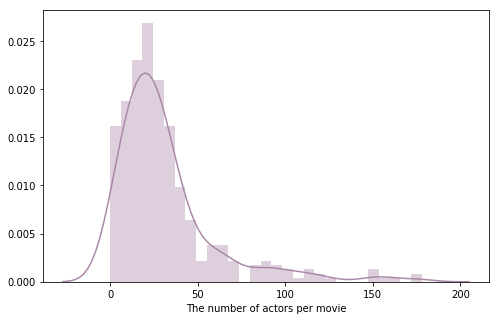

> - 평균적으로 한편의 영화에 31명정도의 배우가 출연하며 많게는 100명 이상의 배우가 출연한다.
> - 하지만 이들 중 대부분은 단역배우이며 주연, 조연을 맡은 배우들에 비해 영화 관객수에 영향을덜 미칠 것이다.
> - 따라서 영화 1편당 비중이 높은 **15명**의 배우만을 택해서 분석에 활용한다.

### 영화 배우별 평균 관객수 순위

**count** : 2015~2019 기간 출연 영화 수

[interactive chart not shown]

> - 점의 크기는 출연영화수가 많을수록 크게나타남
> - 표준편차가 아닌 변동계수를 사용한 이유는 표준편차는 평균에 비례하는 경향이 있기 때문에 상대적으로 영화 관객수가 얼마나 변동이 있는지를 나타내기 위해서는 변동계수가 적합

[interactive chart not shown]

> - **황정민**이 5년간 출연한 영화의 평균 관객수가 740만명정도로 전체 1위를 차지했다.
> - 10위권에 드는 배우의 경우 평균 관객수가 모두 500만 이상으로 **전체 영화의 평균 관객수(143만)**를 훨씬 웃도는 수치이다.
> - 변동계수또한 황정민이 가장 낮았는데(Top20 scatter plot) 이는 황정민이 출연한 영화들의 관객수 편차가 작다는 뜻이며 그가 출연한 영화들의 대부분은 **어느정도 이상의 성공**을 거두었음을 의미한다.
> - Top20 scatter plot에서 변동계수가 가장 큰 김향기, 도경수, 김동욱, 김해숙은 모두 **신과함께**에 출연했다는 공통점이 있다. 이는 신과함께 1,2가 엄청난 흥행을 했기 때문이며 이들이 평균관객수 top20위권에 들 수 있게된 가장 큰 이유일 것이다. 하지만 신과함께는 이들이 출연한 다른 영화들에 비해 상대적으로 높은 관객수를 기록했기 때문에 변동계수 또한 높게 나타났다.
> - **하정우**(2위)의 경우 마찬가지로 신과함께 1,2에 출연했지만 변동계수가 낮은 이유는 그가 출연한 다른영화도 대체적으로 흥행에 성공했기 때문이다.

### 배우별, 장르별 출연 횟수 및 누적 관객수(평균관객수 Top10 배우)

[interactive chart not shown]

> - 10명의 배우가 출연한 영화중 **드라마** 장르의 횟수는 24회로 장르 1위를 차지했으며 액션이 15회로 2위, 코미디, 판타지가 10회로 3위를 차지했다.
> - 대부분의 배우는 4~5개의 장르에 골고루 참여했다.
> - 유해진은 드라마장르, 이동휘는 코미디장르에 참여한 비율이 높았다.

[interactive chart not shown]

> - 누적 관객수의 경우 액션 장르가 7920만(79.2M)명으로 1위를, 판타지가 6980만명으로 2위를 차지했는데 판타지의 경우 **신과함께**의 영향이 크게 작용했기 때문이다.
> - 드라마의 경우 횟수는 24회로 1위를 했지만 누적관객수는 4590만명으로 3위를 차지했다. 이는 드라마 장르 영화의 평균 관객수가 낮았기 때문이다.
> - 전체적으로 대부분의 배우들이 액션이나 판타지 장르에서 높은 누적 관객수를 기록했는데 이는 특정 영화의 영향력이 컸기 때문이고(판타지-신과함께, 액션-베테랑, 암살 등) 이로 인해 '오달수는 판타지 장르에서 강세를 보인다'와 같은 섣부른 결론을 내리는 것에는 한계가 있다고 생각된다.